# R Notebook

**The motivation for the project is to see on what basis stars are assigned to hotels and which attributes influence them.**

**Our class label is ” hotel stars”, and after several experiments we discovered that the attributes affecting it were (Pool + Gym + Spa + Free.internet + Tennis.court + Casino), so we chose it, but the rest did not make a difference in the result.**

**We will predict the Hotel star based on (Pool + Gym + Spa + Free.internet + Tennis.court + Casino)**

**read the dataset**

```r
dataset<-read.csv('dataset.csv')
View(dataset)
str(dataset)
```

```
## 'data.frame':    504 obs. of  20 variables:
##  $ User.country     : chr  "USA" "USA" "USA" "UK" ...
##  $ Nr..reviews      : int  11 119 36 14 5 31 45 2 24 12 ...
##  $ Nr..hotel.reviews: int  4 21 9 7 5 8 12 1 3 7 ...
##  $ Helpful.votes    : int  13 75 25 14 2 27 46 4 8 11 ...
##  $ Score            : int  5 3 5 4 4 3 4 4 4 3 ...
##  $ Period.of.stay   : chr  "Dec-Feb" "Dec-Feb" "Mar-May" "Mar-May" ...
##  $ Traveler.type    : chr  "Friends" "Business" "Families" "Friends" ...
##  $ Pool             : chr  "NO" "NO" "NO" "NO" ...
##  $ Gym              : chr  "YES" "YES" "YES" "YES" ...
##  $ Tennis.court     : chr  "NO" "NO" "NO" "NO" ...
##  $ Spa              : chr  "NO" "NO" "NO" "NO" ...
##  $ Casino           : chr  "YES" "YES" "YES" "YES" ...
##  $ Free.internet    : chr  "YES" "YES" "YES" "YES" ...
##  $ Hotel.name       : chr  "Circus Circus Hotel & Casino Las Vegas" "Circus Circus Hotel & Casino Las Vegas" "Circus Circus Hotel & Casino Las Vegas" "Circus Circus Hotel & Casino Las Vegas" ...
##  $ Hotel.stars      : num  3 3 3 3 3 3 3 3 3 3 ...
##  $ Nr..rooms        : int  3773 3773 3773 3773 3773 3773 3773 3773 3773 3773 ...
##  $ User.continent   : chr  "North America" "North America" "North America" "Europe" ...
##  $ Member.years     : int  9 3 2 6 7 2 4 0 3 5 ...
##  $ Review.month     : chr  "January" "January" "February" "February" ...
##  $ Review.weekday.  : chr  "Thursday," "Friday," "Saturday," "Friday," ...
```

**pie chart for Traveler.type**

```r
library(dplyr)
```

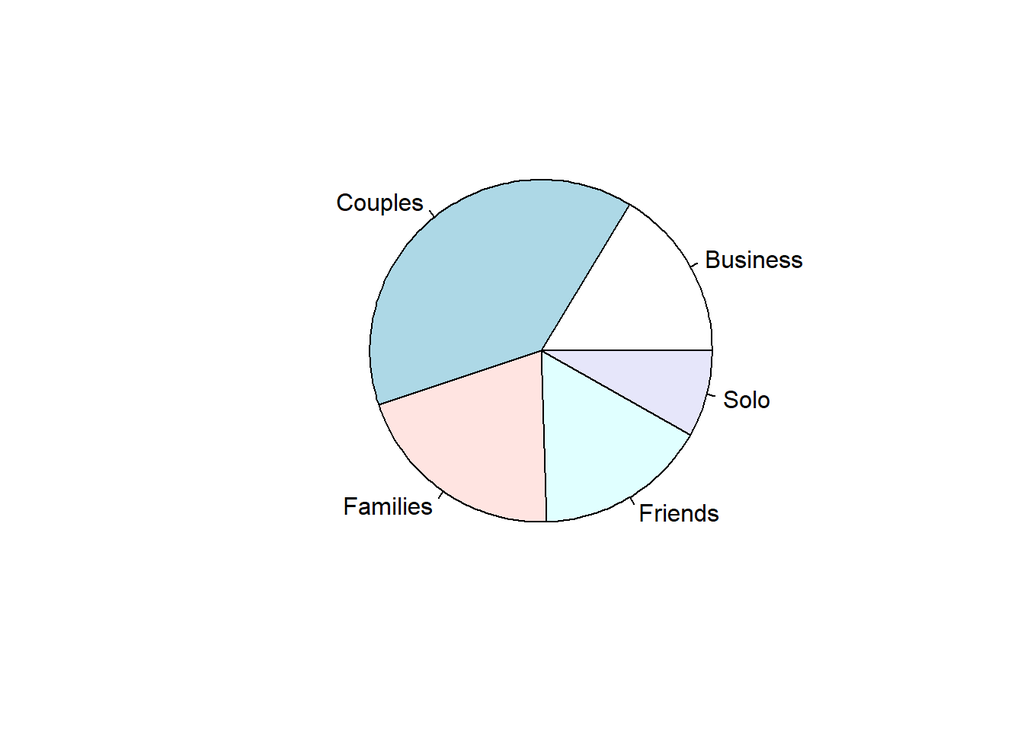

```r
dataset2 <- dataset %>% sample_n(49)
dataset2$Traveler.type %>% table() %>% pie() # plot pie chart without percentages
```

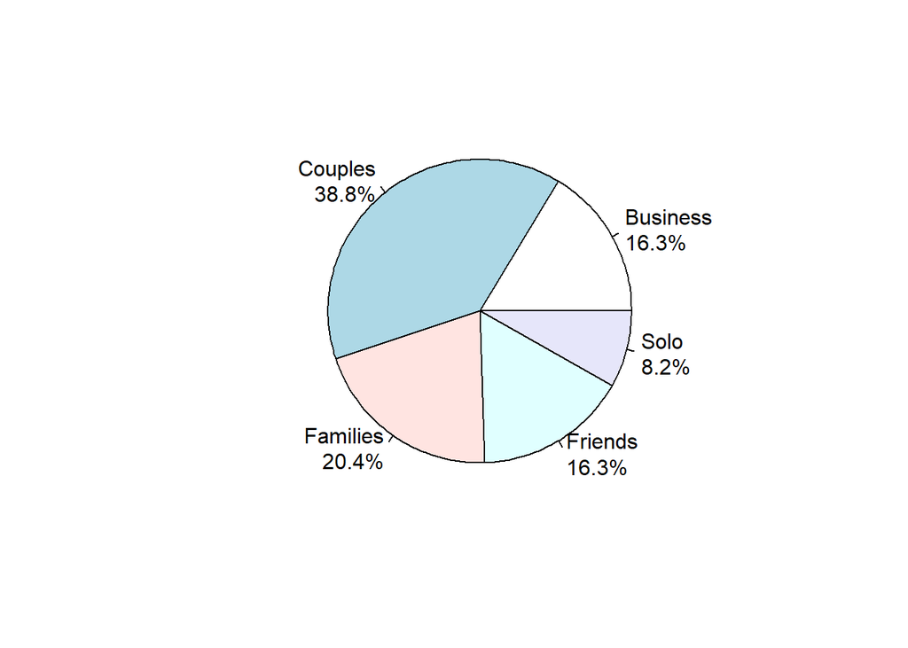

```r
tab <- dataset2$Traveler.type %>% table()
precentages <- tab %>% prop.table() %>% round(3) * 100
txt <- paste0(names(tab), '\n', precentages, '%') # text on chart
pie(tab, labels=txt) # plot pie chart
```

**encoding for all the atribiue**

```r
#encoding
dataset$User.country =factor(dataset$User.country, levels = c("Saudi Arabia", "UK", "Canada", "India", "Australia", "New Zeland", "Ireland", "Egypt", "Finland", "Kenya", "Jordan", "Netherlands", "Syria", "Scotland", "South Africa", "Swiss", "United Arab Emirates", "Hungary", "China", "Greece", "Mexico", "Croatia", "Germany", "Malaysia", "Thailand", "Phillippines", "Israel", "India", "Belgium", "Puerto Rico", "Switzerland", "Norway", "France", "Spain", "Singapore", "Brazil", "Costa Rica", "Iran", "USA", "Honduras", "Denmark", "Taiwan", "Hawaii", "Kuwait", "Czech Republic", "Japan", "Korea", "Italy"),
                          labels =c(1, 2, 3, 4, 5, 6, 7, 8, 9, 10, 11, 12, 13, 14, 15, 16, 17, 18, 19, 20, 21, 22, 23, 24, 25, 26, 27, 28, 29, 30, 31, 32, 33, 34, 35, 36, 37, 38, 39, 40, 41, 42, 43, 44, 45, 46, 47, 48))
#to integer
#dataset$User.country <- as.integer(dataset$User.country)


dataset$Gym =factor(dataset$Gym, levels = c("NO", "YES"), labels = c(0, 1))
dataset$Tennis.court =factor(dataset$Tennis.court, levels = c("NO", "YES"), labels = c(0, 1))

dataset$Spa =factor(dataset$Spa, levels = c("NO", "YES"), labels = c(0, 1))

dataset$Casino =factor(dataset$Casino, levels = c("NO", "YES"), labels = c(0, 1))
dataset$Free.internet =factor(dataset$Free.internet, levels = c("NO", "YES"), labels = c(0, 1))

dataset$Pool =factor(dataset$Pool, levels = c("NO", "YES"), labels = c(0, 1))

dataset$Period.of.stay =factor(dataset$Period.of.stay, levels = c("Dec-Feb", "Mar-May","Jun-Aug","Sep-Nov"), labels = c(1, 2, 3, 4))


dataset$Review.weekday. =factor(dataset$Review.weekday , levels = c("Thursday","Thursday,","Friday","Friday,","Saturday","Saturday,","Tuesday","Tuesday,","Wednesday","Wednesday,","Sunday","Sunday,","Monday","Monday,"), labels = c(0,0,1,1,2,2,3,3,4,4,5,5,6,6))
dataset$Traveler.type =factor(dataset$Traveler.type, levels = c("Friends","Solo","Families","Couples","Business"), labels = c(0,1,2,3,4))

dataset$Hotel.name =factor(dataset$Hotel.name, levels = c("Circus Circus Hotel & Casino Las Vegas","Excalibur Hotel & Casino", "Monte Carlo Resort&Casino", "Treasure Island- TI Hotel & Casino", "Tropicana Las Vegas - A Double Tree by Hilton Hotel", "Caesars Palace", "The Cosmopolitan Las Vegas", "The Palazzo Resort Hotel Casino", "Wynn Las Vegas", "Trump International Hotel Las Vegas", "The Cromwell", "Encore at wynn Las Vegas", "Hilton Grand Vacations on the Boulevard", "Marriott's Grand Chateau", "Tuscany Las Vegas Suites & Casino", "Hilton Grand Vacations at the Flamingo", "Wyndham Grand Desert", "The Venetian Las Vegas Hotel", "Bellagio Las Vegas", "Paris Las Vegas", "The Westin las Vegas Hotel Casino & Spa")
                           , labels = c(0,1,2,3,4,5,6,7,8,9,10,11,12,13,14,15,16,17,18,19,20))

dataset$Review.month =factor(dataset$Review.month, levels = c("April","August", "December", "February", "January", "July", "June", "March", "May", "November", "October", "September")
                           , labels = c(0,1,2,3,4,5,6,7,8,9,10,11))

dataset$User.continent=factor(dataset$User.continent, levels=c("North America","Europe","Asia","Oceania","Africa","South America"), labels=c(0,1,2,3,4,5))
```

**finding outliers AND remove outliers**